# Using Global Vectors for Getting Semantic Fields

Andreas Blätte

2017-01-19

Vector representations for words are becoming popular in text mining. In particular, the text2vec algorithm (by Tomáš Mikolov) and the GloVe algorithm (by Jeffrey Pennington, Richard Socher and Christopher D. Manning) have attracted considerable attention - including mine.

These algorithms generate a vector representation of words based on term cooccurrence matrices. Word vectors capture the semantics of a word based on its neighborhood in a low-dimensional fashion. This is an appealing intuition. There is a wealth of use cases that go beyond the relatively basic scenario I explore here: Are vector represenations for words useful to have a take the vocabulary of a semantic field?

## Preliminary I: Getting started

To get started, I load the polmineR package, and the data.table package which I will use later on.

```r
library(polmineR)
library(data.table)
use("plprbt")
```

## Preliminary II: The vocabulary of interest

Very rare words will not be interesting. We perform a word count for the corpus (PLPRBT), and discard all words that to not occur at least 10 times.

```r
PLPRBT <- Corpus$new("PLPRBT")
PLPRBT$count(pAttribute = "word")
vocabulary <- PLPRBT$stat[count >= 10][["word"]]
```

I have really spent a lot of time cleaning my corpus of parliamentary debates. It is still necessary to get rid of noise.

```r
vocabulary <- vocabulary[-which(vocabulary %in% unlist(noise(vocabulary)))]
```

The resulting vocabulary includes 112462 tokens. Being more conservative and applying a higher minimum word occurrence threshold would have been possible. Yet I want to suffer. To test performance, I did not want to keep object sizes minimal here.

## Generating the term cooccurrence matrix

The GloVe algorithm will require a term cooccurrence matrix as input. I am somewhat proud in that respect: In the most recent version of the polmineR package (dev branch on GitHub), I have introduced a cooccurrences method for character class objects that will generate the term cooccurrence matrix for a whole corpus in a somewhat optimized manner.

On my laptop (a Macbook Pro, 256 GB SSD, 2,6 GHz i5), getting the term cooccurrence matrix for the 105 M corpus takes 10 minutes. No doubt, an optimized C implementation will be much faster. For me, at this stage, I can take waiting 10 minutes.

At this stage, there is a technical detail to take care of. The cooccurrences method returns a sparse matrix (of class ‘simple triplet matrix’). The GloVe class requires a ‘dgTMatrix’ as an input, one of the classes defined in the Matrix package (a compressed, sparse, column-oriented format). The as.sparseMatrix method in the polmineR package will generate a ‘dgCMatrix’. From that point, a coerce method defined in the Matrix package can be used.

Now, we a few big and bulky objects in memory. When working on this post, I was not very cautious at all times and I ran out of memory (16 GB) several times. Objects that are not needed any longer can be removed, to avoid that.

```r
rm(PLPRBT_tcm_slam, PLPRBT_tcm_dgCMatrix)
```

## Running the GloVe algorithm

The text2vec package claims to be particularly fast at generating anything you need for bag-of-words-operations. It is not that part of the functionality I really need. Yet I was really happy to discover that the text2vec package includes an implementation of the GloVe algorithm. After initializing the class, we can run the global vectors algorithm.

```r
glove_word_vectors <- GV$get_word_vectors()
```

There are many useful things you can do with word vectors. For instance, I have played with word vectors for calculating sentence similarity. Here, I wish to keep it simple, and work with word similarity.

## Dictionaries and semantic fields: A first take

Word vectors can be used to find similar words to a query by calculating the cosine similarity of the vector for the query with the vectors of all other words. The result may be considered as the vocabulary of a semantic field.

To assist running that operation more often than once, let us prepare a small convenience function that will calculate the cosine similarity, put the result in a data.table, merge in word counts, order the result based on cosine similarity and return just the top n words.

```r
get_semantic_field <- function(query, n = NULL, count = PLPRBT$stat){
  query_vector <- matrix(glove_word_vectors[query,], nrow = 1)
  similarities <- proxy::simil(x = glove_word_vectors, y = query_vector, method = "cosine")
  similarities_dt <- data.table(word = rownames(similarities), cosine = similarities[,1])
  setkeyv(similarities_dt, cols = "word")
  similarities_dt <- count[similarities_dt]
  setorderv(similarities_dt, cols = "cosine", order = -1)
  similarities_dt <- similarities_dt[2:nrow(similarities_dt),]
  if (!is.null(n)) similarities_dt <- head(similarities_dt, n = n)
  similarities_dt
}
```

## Results

So we are ready to get results for three keywords in Germany’s debates on migration and integration (“Zuwanderung”, “Asyl”, “Islam”). Although word clouds are always very illustrative, I prefer Cleveland dot plots as a simlple visualisation, as they convey information in a very intuitive manner.

**Zuwanderung**

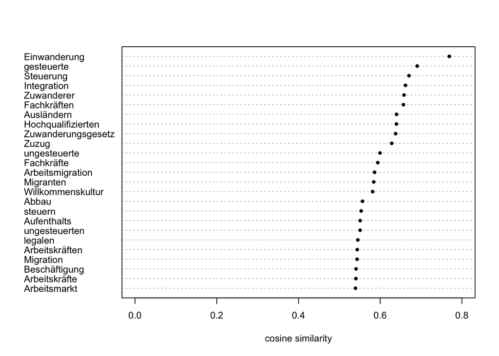

```r
zuwanderung <- get_semantic_field("Zuwanderung", 25)
dotchart(
  x = rev(zuwanderung[["cosine"]]),
  labels = rev(zuwanderung[["word"]]),
  pch = 20, cex = 0.8, xlim = c(0, 0.8),
  xlab = "cosine similarity"
  )
```

**Asyl**

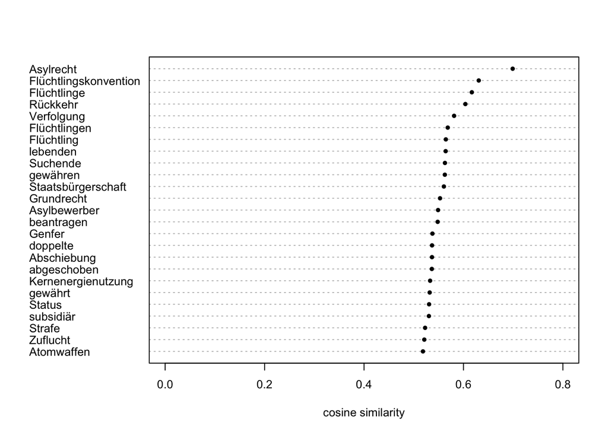

```r
asyl <- get_semantic_field("Asyl", 25)
dotchart(
  x = rev(asyl[["cosine"]]),
  labels = rev(asyl[["word"]]),
  pch = 20, cex = 0.8, xlim = c(0, 0.8),
  xlab = "cosine similarity"
  )
```

**Islam**

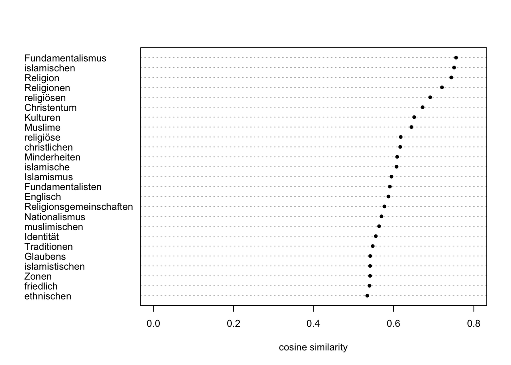

```r
islam <- get_semantic_field("Islam", 25)
dotchart(
  x = rev(islam[["cosine"]]), labels = rev(islam[["word"]]),
  pch = 20, cex = 0.8, xlim = c(0, 0.8),
  xlab = "cosine similarity"
  )
```

## Discussion

Applications of word vectors go beyond that. At this stage, I am satisfied to dip into the usefulness of this analytical technique, and to demonstrate that there is a smooth way from a CWB corpus accessed with the polmineR package to the term cooccurrence matrix to be processed with the GloVe class in the text2vec package.